# Analyzing the Reptile data for State of Nature Report 2023

## Loess

Next, study species richness in the loess. Let’s start with data visualization:

```r
## Loess species richness----
loess <- alpha.div[unit == 'Loess Covered Areas in the Northern Negev']
loess[campaign == 'T0', ':=' (year = 2014, year.fct = as.factor(2014))]

str(loess)
```

```
## Classes 'data.table' and 'data.frame':   112 obs. of  23 variables:
##  $ unit               : Factor w/ 5 levels "Coastal Plain Sands",..: 3 3 3 3 3 3 3 3 3 3 ...
##  $ year               : num  2014 2014 2014 2014 2014 ...
##  $ campaign           : Factor w/ 5 levels "T0","T1","T2",..: 1 1 1 1 1 1 1 1 1 1 ...
##  $ subunit            : Factor w/ 3 levels "Carmel","Galilee",..: NA NA NA NA NA NA NA NA NA NA ...
##  $ site               : Factor w/ 35 levels "Aderet","Amatzia",..: 11 11 11 14 14 14 24 24 24 24 ...
##  $ point_name         : Factor w/ 281 levels "Aderet 31.67144877_34.9880248",..: 87 88 91 108 109 110 184 185 186 187 ...
##  $ survey_ID          : Factor w/ 691 levels "T0_Aderet 31.67867469_34.98154177",..: 40 41 42 49 50 51 88 89 90 91 ...
##  $ Date               : Date, format: "2014-06-16" "2014-06-16" ...
##  $ sin.dist.21.June   : num  -0.086 -0.086 -0.086 0.171 0.171 ...
##  $ cos.dist.21.June   : num  0.996 0.996 0.996 0.985 0.985 ...
##  $ sin.dist.noon      : num  -0.165 -0.375 -0.676 -0.375 -0.462 ...
##  $ cos.dist.noon      : num  0.986 0.927 0.737 0.927 0.887 ...
##  $ settlements        : Factor w/ 2 levels "Far","Near": NA NA NA NA NA NA NA NA NA NA ...
##  $ agriculture        : Factor w/ 2 levels "Far","Near": NA NA NA NA NA NA NA NA NA NA ...
##  $ dunes              : Factor w/ 2 levels "semi-shifting",..: NA NA NA NA NA NA NA NA NA NA ...
##  $ habitat            : Factor w/ 3 levels "bedouin agriculture",..: 1 1 1 1 1 1 1 1 1 2 ...
##  $ mean.lon           : num  34.7 34.7 NaN 34.8 34.8 ...
##  $ mean.lat           : num  31.3 31.3 NaN 31.4 31.4 ...
##  $ species.richness   : num  2 1 0 1 2 1 2 1 1 0 ...
##  $ total.abundance    : num  6 3 0 4 7 4 6 2 5 0 ...
##  $ geom.mean.abundance: num  2.24 3 0 4 2.45 ...
##  $ year.count         : num  0 0 0 0 0 0 0 0 0 0 ...
##  $ year.fct           : Factor w/ 8 levels "2014","2015",..: 1 1 1 1 1 1 1 1 1 1 ...
##  - attr(*, "sorted")= chr "unit"
##  - attr(*, ".internal.selfref")=<externalptr>
```

```r
loess[is.na(habitat)] # no missing variables
```

```
## Key: <unit>
## Empty data.table (0 rows and 23 cols): unit,year,campaign,subunit,site,point_name...
```

```r
loess[, sort(unique(year)), keyby = campaign] # 2014-2020 every 2 years
```

```
## Key: <campaign>
##    campaign    V1
##      <fctr> <num>
## 1:       T0  2014
## 2:       T1  2016
## 3:       T2  2018
## 4:       T3  2020
```

```r
loess[, .(no.of.sites = uniqueN(site)), keyby = .(campaign, year)]
```

```
## Key: <campaign, year>
##    campaign  year no.of.sites
##      <fctr> <num>       <int>
## 1:       T0  2014           6
## 2:       T1  2016           7
## 3:       T2  2018           7
## 4:       T3  2020           7
```

```r
loess[, .(no.of.surveys = uniqueN(survey_ID)), keyby = .(campaign, year, site)]
```

```
## Key: <campaign, year, site>
##     campaign  year            site no.of.surveys
##       <fctr> <num>          <fctr>         <int>
##  1:       T0  2014    Eshel Hanasi             3
##  2:       T0  2014       Givot Bar             3
##  3:       T0  2014 Mishmar Hanegev             6
##  4:       T0  2014     Nahal Ashan             6
##  5:       T0  2014      Park Loess             3
##  6:       T0  2014  Sayeret Shaked             6
##  7:       T1  2016    Eshel Hanasi             3
##  8:       T1  2016       Givot Bar             3
##  9:       T1  2016           Goral             3
## 10:       T1  2016 Mishmar Hanegev             6
## 11:       T1  2016     Nahal Ashan             6
## 12:       T1  2016      Park Loess             3
```

[output cut: 16 more lines]

```r
loess[, .(no.of.surveys = uniqueN(survey_ID)), keyby = .(campaign, year, site, habitat)]
```

```
## Key: <campaign, year, site, habitat>
##     campaign  year            site             habitat no.of.surveys
##       <fctr> <num>          <fctr>              <fctr>         <int>
##  1:       T0  2014    Eshel Hanasi bedouin agriculture             3
##  2:       T0  2014       Givot Bar bedouin agriculture             3
##  3:       T0  2014 Mishmar Hanegev bedouin agriculture             3
##  4:       T0  2014 Mishmar Hanegev       kkl plantings             3
##  5:       T0  2014     Nahal Ashan       kkl plantings             3
##  6:       T0  2014     Nahal Ashan               loess             3
##  7:       T0  2014      Park Loess               loess             3
##  8:       T0  2014  Sayeret Shaked       kkl plantings             3
##  9:       T0  2014  Sayeret Shaked               loess             3
## 10:       T1  2016    Eshel Hanasi bedouin agriculture             3
## 11:       T1  2016       Givot Bar bedouin agriculture             3
## 12:       T1  2016           Goral bedouin agriculture             3
```

[output cut: 28 more lines]

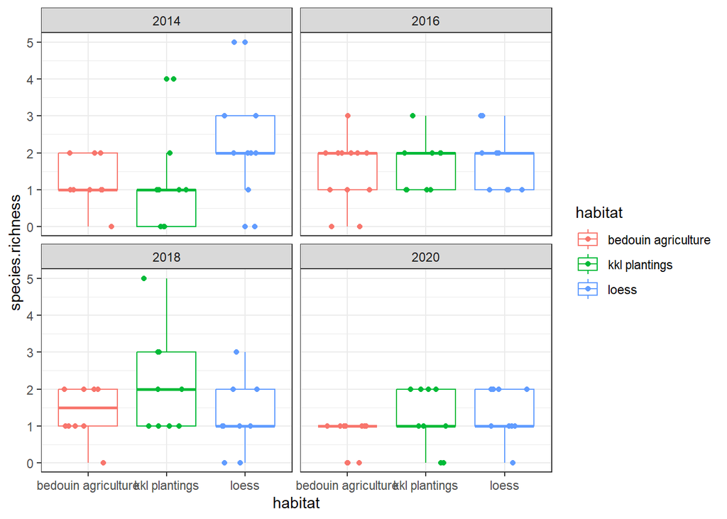

```r
# Plot species richness
ggplot(data = loess, aes(x = habitat, color = habitat, y = species.richness)) + geom_boxplot() +
  geom_jitter(height = 0, width = 0.3) +  facet_wrap(. ~ year) + theme_bw()
```

Habitat and annual differences seem minor

Next, model selection, starting from the full model with Poisson response:

```r
# Species richness model selection----
loess.sp.rich.model.full.Poisson <- glmmTMB(species.richness ~ year.count * habitat + sin.dist.21.June + cos.dist.21.June +
                                sin.dist.noon + cos.dist.noon + (1|site), family = 'poisson', data = loess)
summary(loess.sp.rich.model.full.Poisson) # AIC = 314.3 BIC = 344.2
```

```
##  Family: poisson  ( log )
## Formula:          species.richness ~ year.count * habitat + sin.dist.21.June +
##     cos.dist.21.June + sin.dist.noon + cos.dist.noon + (1 | site)
## Data: loess
##
##      AIC      BIC   logLik deviance df.resid
##    314.3    344.2   -146.1    292.3      101
##
## Random effects:
##
## Conditional model:
##  Groups Name        Variance  Std.Dev.
##  site   (Intercept) 1.314e-09 3.625e-05
## Number of obs: 112, groups:  site, 7
##
## Conditional model:
##                                  Estimate Std. Error z value Pr(>|z|)
## (Intercept)                      1.588243   0.774277   2.051  0.04024 *
## year.count                      -0.069082   0.078805  -0.877  0.38069
## habitatkkl plantings            -0.187927   0.356140  -0.528  0.59772
## habitatloess                     0.224795   0.344482   0.653  0.51404
## sin.dist.21.June                 0.661342   0.403815   1.638  0.10148
## cos.dist.21.June                -2.361546   0.832444  -2.837  0.00456 **
## sin.dist.noon                    0.521905   0.218384   2.390  0.01686 *
## cos.dist.noon                    1.212698   0.520543   2.330  0.01982 *
## year.count:habitatkkl plantings  0.116072   0.099239   1.170  0.24215
## year.count:habitatloess          0.007714   0.096967   0.080  0.93660
## ---
## Signif. codes:  0 '***' 0.001 '**' 0.01 '*' 0.05 '.' 0.1 ' ' 1
```

```r
cat('PHI = '); deviance(loess.sp.rich.model.full.Poisson)/df.residual(loess.sp.rich.model.full.Poisson)
```

```
## PHI =
```

```
## [1] 0.6117383
```

```r
drop1(loess.sp.rich.model.full.Poisson) # Can drop the interaction
```

```
## Single term deletions
##
## Model:
## species.richness ~ year.count * habitat + sin.dist.21.June +
##     cos.dist.21.June + sin.dist.noon + cos.dist.noon + (1 | site)
##                    Df    AIC
## <none>                314.26
## sin.dist.21.June    1 314.94
## cos.dist.21.June    1 319.92
## sin.dist.noon       1 318.17
## cos.dist.noon       1 318.34
## year.count:habitat  2 312.25
```

Since PHI < 1, we proceed with Poisson models. We can drop the interaction between trend and habitat.

```r
loess.sp.rich.model1 <- glmmTMB(species.richness ~ year.count + habitat + sin.dist.21.June + cos.dist.21.June +
                                sin.dist.noon + cos.dist.noon + (1|site), family = 'poisson', data = loess)
summary(loess.sp.rich.model1)
```

```
##  Family: poisson  ( log )
## Formula:          species.richness ~ year.count + habitat + sin.dist.21.June +
##     cos.dist.21.June + sin.dist.noon + cos.dist.noon + (1 | site)
## Data: loess
##
##      AIC      BIC   logLik deviance df.resid
##    312.3    336.7   -147.1    294.3      103
##
## Random effects:
##
## Conditional model:
##  Groups Name        Variance  Std.Dev.
##  site   (Intercept) 1.575e-09 3.969e-05
## Number of obs: 112, groups:  site, 7
##
## Conditional model:
##                      Estimate Std. Error z value Pr(>|z|)
## (Intercept)           1.57511    0.73435   2.145  0.03196 *
## year.count           -0.02541    0.04211  -0.603  0.54623
## habitatkkl plantings  0.14480    0.21622   0.670  0.50308
## habitatloess          0.23287    0.23642   0.985  0.32464
## sin.dist.21.June      0.67276    0.40475   1.662  0.09648 .
## cos.dist.21.June     -2.36570    0.82226  -2.877  0.00401 **
## sin.dist.noon         0.55166    0.21752   2.536  0.01121 *
## cos.dist.noon         1.09770    0.49983   2.196  0.02808 *
## ---
## Signif. codes:  0 '***' 0.001 '**' 0.01 '*' 0.05 '.' 0.1 ' ' 1
```

```r
drop1(loess.sp.rich.model1)
```

```
## Single term deletions
##
## Model:
## species.richness ~ year.count + habitat + sin.dist.21.June +
##     cos.dist.21.June + sin.dist.noon + cos.dist.noon + (1 | site)
##                  Df    AIC
## <none>              312.25
## year.count        1 310.62
## habitat           2 309.23
## sin.dist.21.June  1 313.01
## cos.dist.21.June  1 318.05
## sin.dist.noon     1 316.93
## cos.dist.noon     1 315.58
```

We can drop the habitat altogether, but before we so, let’s compare the p-values of comparing the habitats to each other:

```r
EMM <- emmeans(object = loess.sp.rich.model1, ~habitat + year.count)
test_results_land_use <- test(pairs(EMM, by = 'year.count'), by = NULL, adjust="fdr")
print(test_results_land_use)
```

```
##  contrast                            year.count estimate    SE  df z.ratio
##  bedouin agriculture - kkl plantings       2.98  -0.1448 0.216 Inf  -0.670
##  bedouin agriculture - loess               2.98  -0.2329 0.236 Inf  -0.985
##  kkl plantings - loess                     2.98  -0.0881 0.198 Inf  -0.444
##  p.value
##   0.6572
##   0.6572
##   0.6572
##
## Results are given on the log (not the response) scale.
## P value adjustment: fdr method for 3 tests
```

And now let’s proceed to dropping the habitat from the model:

```r
loess.sp.rich.model2 <- glmmTMB(species.richness ~ year.count + sin.dist.21.June + cos.dist.21.June +
                                sin.dist.noon + cos.dist.noon + (1|site), family = 'poisson', data = loess)
summary(loess.sp.rich.model2)
```

```
##  Family: poisson  ( log )
## Formula:
## species.richness ~ year.count + sin.dist.21.June + cos.dist.21.June +
##     sin.dist.noon + cos.dist.noon + (1 | site)
## Data: loess
##
##      AIC      BIC   logLik deviance df.resid
##    309.2    328.3   -147.6    295.2      105
##
## Random effects:
##
## Conditional model:
##  Groups Name        Variance  Std.Dev.
##  site   (Intercept) 0.0008169 0.02858
## Number of obs: 112, groups:  site, 7
##
## Conditional model:
##                  Estimate Std. Error z value Pr(>|z|)
## (Intercept)       1.51728    0.72933   2.080  0.03749 *
## year.count       -0.03359    0.04141  -0.811  0.41719
## sin.dist.21.June  0.50367    0.36413   1.383  0.16660
## cos.dist.21.June -2.10546    0.77047  -2.733  0.00628 **
## sin.dist.noon     0.63303    0.20420   3.100  0.00194 **
## cos.dist.noon     1.01817    0.48928   2.081  0.03744 *
## ---
## Signif. codes:  0 '***' 0.001 '**' 0.01 '*' 0.05 '.' 0.1 ' ' 1
```

```r
drop1(loess.sp.rich.model2)
```

```
## Single term deletions
##
## Model:
## species.richness ~ year.count + sin.dist.21.June + cos.dist.21.June +
##     sin.dist.noon + cos.dist.noon + (1 | site)
##                  Df    AIC
## <none>              309.23
## year.count        1 307.89
## sin.dist.21.June  1 309.14
## cos.dist.21.June  1 314.11
## sin.dist.noon     1 317.02
## cos.dist.noon     1 312.06
```

We can also drop the trend:

```r
loess.sp.rich.model3 <- glmmTMB(species.richness ~ sin.dist.21.June + cos.dist.21.June +
                                sin.dist.noon + cos.dist.noon + (1|site), family = 'poisson', data = loess)
summary(loess.sp.rich.model3)
```

```
##  Family: poisson  ( log )
## Formula:
## species.richness ~ sin.dist.21.June + cos.dist.21.June + sin.dist.noon +
##     cos.dist.noon + (1 | site)
## Data: loess
##
##      AIC      BIC   logLik deviance df.resid
##    307.9    324.2   -147.9    295.9      106
##
## Random effects:
##
## Conditional model:
##  Groups Name        Variance Std.Dev.
##  site   (Intercept) 0.002592 0.05092
## Number of obs: 112, groups:  site, 7
##
## Conditional model:
##                  Estimate Std. Error z value Pr(>|z|)
## (Intercept)        1.4704     0.7332   2.005  0.04492 *
## sin.dist.21.June   0.6131     0.3471   1.766  0.07734 .
## cos.dist.21.June  -2.1919     0.7699  -2.847  0.00441 **
## sin.dist.noon      0.6163     0.2054   3.000  0.00270 **
## cos.dist.noon      1.0802     0.4813   2.244  0.02482 *
## ---
## Signif. codes:  0 '***' 0.001 '**' 0.01 '*' 0.05 '.' 0.1 ' ' 1
```

```r
drop1(loess.sp.rich.model3)
```

```
## Single term deletions
##
## Model:
## species.richness ~ sin.dist.21.June + cos.dist.21.June + sin.dist.noon +
##     cos.dist.noon + (1 | site)
##                  Df    AIC
## <none>              307.89
## sin.dist.21.June  1 309.06
## cos.dist.21.June  1 313.56
## sin.dist.noon     1 315.16
## cos.dist.noon     1 311.62
```

We can drop sine seasonality since delta AIC < 2:

```r
loess.sp.rich.model4 <- glmmTMB(species.richness ~ cos.dist.21.June + sin.dist.noon + cos.dist.noon + (1|site), family = 'poisson', data = loess)
summary(loess.sp.rich.model4)
```

```
##  Family: poisson  ( log )
## Formula:
## species.richness ~ cos.dist.21.June + sin.dist.noon + cos.dist.noon +
##     (1 | site)
## Data: loess
##
##      AIC      BIC   logLik deviance df.resid
##    309.1    322.6   -149.5    299.1      107
##
## Random effects:
##
## Conditional model:
##  Groups Name        Variance Std.Dev.
##  site   (Intercept) 0.002083 0.04563
## Number of obs: 112, groups:  site, 7
##
## Conditional model:
##                  Estimate Std. Error z value Pr(>|z|)
## (Intercept)        0.5068     0.5089   0.996  0.31931
## cos.dist.21.June  -1.1444     0.5094  -2.247  0.02466 *
## sin.dist.noon      0.5915     0.1962   3.014  0.00258 **
## cos.dist.noon      0.9721     0.4671   2.081  0.03743 *
## ---
## Signif. codes:  0 '***' 0.001 '**' 0.01 '*' 0.05 '.' 0.1 ' ' 1
```